# Stochastic Growth Exercises 1

Ferran Estrella Serra

2026-06-22

## Data Generation

```r
# Summer School in Statistics 2026 - Day 1 Data Generation
set.seed(42)
t_seq <- seq(0, 50, by = 1)
```

## Technical Note: Estimation & Validation

Non-linear Least Squares (nls): To estimate parameters θ in non-linear models (e.g., N(t) = f(t,θ) + eps), use the ‘nls’ function in R. Below is an example of fitting a Logistic growth model:

```r
# Fitting logistic model: N(t) = K / (1 + ((K- N0)/N0) * exp(-r * t))
#fit <- nls(N ~ K / (1 + ((K- N0)/N0) * exp(-r * t)), data = my_data, start = list(r = 0.1, N0 = 10))
#summary(fit)
```

# Exercise 1 (Ecology & Biology)– Fish Population Reintroduction (4 points)

A local environmental agency reintroduced a vulnerable native fish species into a closed lake basin. Biologists monitored the population size N(t) weekly over a year.

1. Given that the underlying carrying capacity of the lake is strictly bounded by space and food, write down the analytical solution of the Logistic growth model.

The analytical solution in such a case is given by N(t)=K/(1+((K-N0)/N0)exp(-rt)) where N0 is the initial population, K is the carrying capacity and r is the growth rate.

2. Using the provided simulated data, estimate the intrinsic growth rate r and the initial population N0 using non-linear least squares (nls in R), assuming a fixed carrying capacity K=1000.

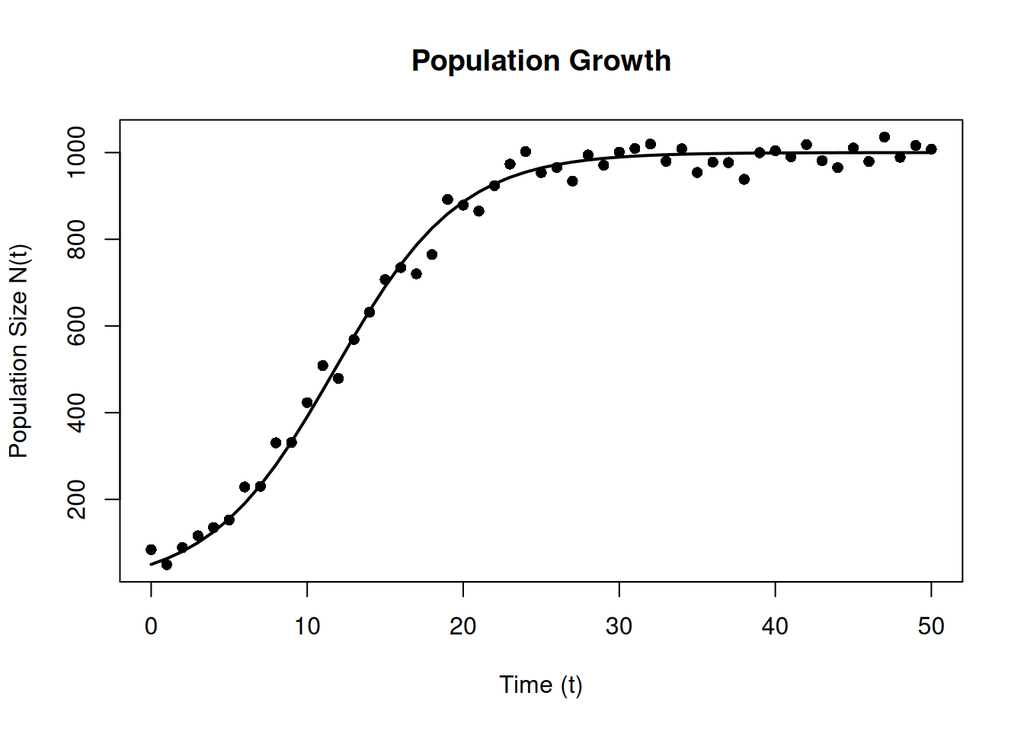

```r
# Logistic Fish Population Data Generation
K_fish <- 1000; N0_fish <- 50; r_fish <- 0.25
fish_clean <- K_fish / (1 + ((K_fish - N0_fish) / N0_fish) * exp(-r_fish * t_seq))
fish_data <- data.frame(time = t_seq, N = fish_clean + rnorm(length(t_seq), mean=0, sd=25))

plot(fish_data$time, fish_data$N,
     xlab = "Time (t)",
     ylab = "Population Size N(t)",
     main = "Population Growth",
     pch = 16)

lines(t_seq, fish_clean, lwd = 2)
```

```r
# Logistic Fish r and N0 inference
fit <- nls(N ~ 1000 / (1 + ((1000- N0)/N0) * exp(-r*time)), data = fish_data, start = list(r = 0.1, N0 = 10))
summary(fit)
```

```
##
## Formula: N ~ 1000/(1 + ((1000 - N0)/N0) * exp(-r * time))
##
## Parameters:
##     Estimate Std. Error t value Pr(>|t|)
## r   0.233008   0.006875   33.89   <2e-16 ***
## N0 61.600351   5.053403   12.19   <2e-16 ***
## ---
## Signif. codes:  0 '***' 0.001 '**' 0.01 '*' 0.05 '.' 0.1 ' ' 1
##
## Residual standard error: 27.19 on 49 degrees of freedom
##
## Number of iterations to convergence: 11
## Achieved convergence tolerance: 1.109e-06
```

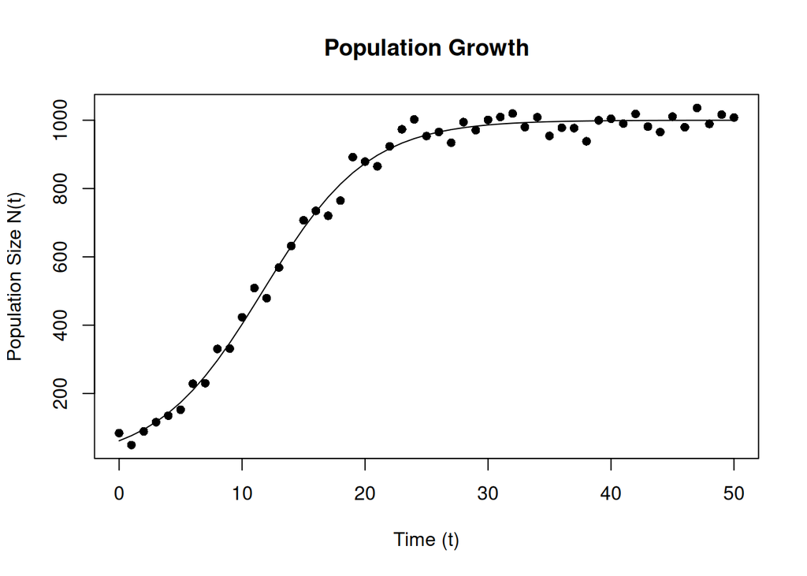

```r
params <- coef(fit)
r_hat  <- params["r"]
N0_hat <- params["N0"]
fish_fitted <- 1000 / (1 + ((1000 - N0_hat) / N0_hat) * exp(-r_hat * t_seq))

plot(fish_data$time, fish_data$N,
     xlab = "Time (t)",
     ylab = "Population Size N(t)",
     main = "Population Growth",
     pch = 16)

lines(t_seq, fish_fitted)
```

3. Analytically calculate the week at which the population absolute growth rate reaches its global maximum phase, and compare it with the inflection point observed visually in the fitted dataset.

$\frac{d}{dt}\frac{dN(t)}{dt}=\frac{dN}{dt}\frac{d}{dN}(\frac{dN(t)}{dt})$ equals 0 for the maximum absolute growth rate for $\frac{d}{dN}(\frac{dN(t)}{dt})=r(1-2N(t)/K)=0$, that is, $N(t)=K/2=500$ and $t=\frac{1}{r}ln(\frac{K-N0}{N0})$:

```r
1/r_fish*log((K_fish-N0_hat)/N0_hat)
```

```
##       N0
## 10.89403
```

This is the same time an inflection point is observed in the fitted dataset.

# Exercise 2 (Economics & Finance)– Technological Innovation Adoption (4 points)

A financial technology firm tracks the cumulative adoption rate N(t) of a new decentralized payment system in a developing country market. The market ceiling is bounded by the total population holding a smartphone.

1. Fit both a standard Logistic model and a Gompertz model to the adoption dataset using least squares estimation.

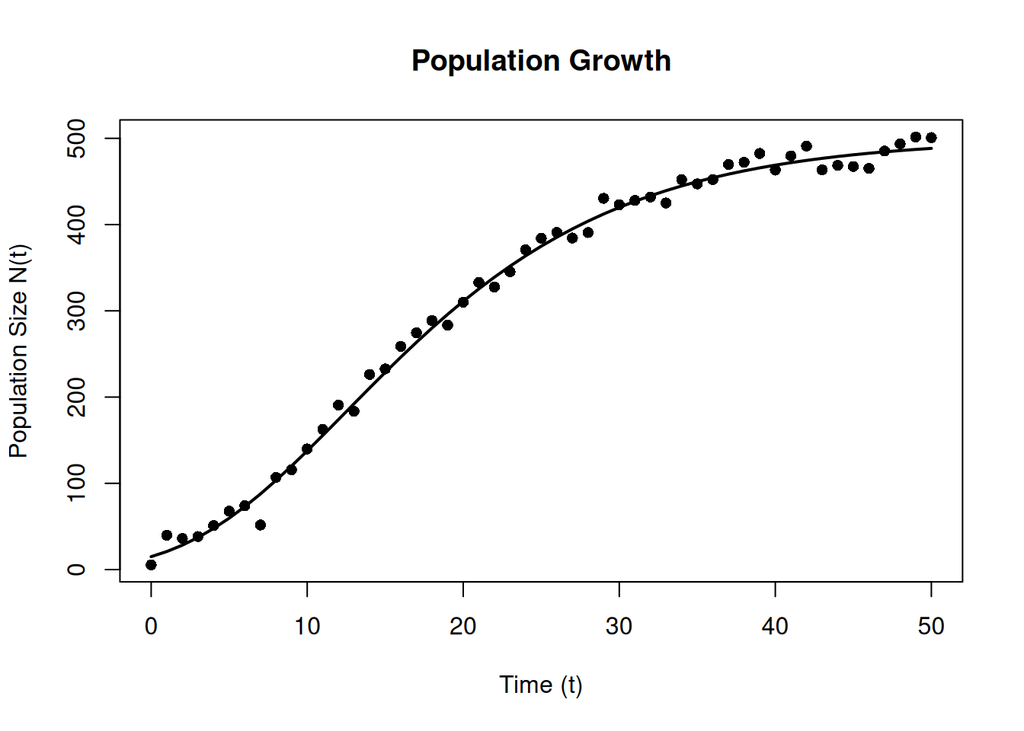

```r
# Ex 2: FinTech Innovation (Gompertz underlying structure)
K_tech <- 500; N0_tech <- 15; r_tech <- 0.10
tech_clean <- K_tech * exp(log(N0_tech / K_tech) * exp(-r_tech * t_seq))
tech_data <- data.frame(time = t_seq, N = tech_clean + rnorm(length(t_seq), mean=0, sd=12))

plot(tech_data$time, tech_data$N,
     xlab = "Time (t)",
     ylab = "Population Size N(t)",
     main = "Population Growth",
     pch = 16)

lines(t_seq, tech_clean, lwd = 2)
```

```r
# Logistic Tech r and N0 inference
fit_log <- nls(N ~ K / (1 + ((K-N0)/N0) * exp(-r*time)), data = tech_data, start = list(K=100, r = 0.1, N0 = 10))
summary(fit_log)
```

```
##
## Formula: N ~ K/(1 + ((K - N0)/N0) * exp(-r * time))
##
## Parameters:
##     Estimate Std. Error t value Pr(>|t|)
## K  4.813e+02  4.521e+00  106.47   <2e-16 ***
## r  1.542e-01  5.582e-03   27.62   <2e-16 ***
## N0 3.691e+01  2.977e+00   12.40   <2e-16 ***
## ---
## Signif. codes:  0 '***' 0.001 '**' 0.01 '*' 0.05 '.' 0.1 ' ' 1
##
## Residual standard error: 15.2 on 48 degrees of freedom
##
## Number of iterations to convergence: 8
## Achieved convergence tolerance: 6.973e-06
```

```r
fit_gomp <- nls(N ~ K * exp(log(N0 / K) * exp(-r*time)), data = tech_data, start = list(K=100, r = 0.1, N0 = 10))
summary(fit_gomp)
```

```
##
## Formula: N ~ K * exp(log(N0/K) * exp(-r * time))
##
## Parameters:
##     Estimate Std. Error t value Pr(>|t|)
## K  5.013e+02  4.622e+00  108.47  < 2e-16 ***
## r  9.978e-02  3.021e-03   33.03  < 2e-16 ***
## N0 1.569e+01  2.073e+00    7.57 9.87e-10 ***
## ---
## Signif. codes:  0 '***' 0.001 '**' 0.01 '*' 0.05 '.' 0.1 ' ' 1
##
## Residual standard error: 11.48 on 48 degrees of freedom
##
## Number of iterations to convergence: 6
## Achieved convergence tolerance: 8.192e-06
```

2. Compute the Residual Sum of Squares (RSS) and the Mean Absolute Percentage Error (MAPE) for both models. Determine which mathematical framework provides a better predictive fit for this macroeconomic phenomenon.

```r
(rss_log <- sum((tech_data$N - predict(fit_log))^2))
```

```
## [1] 11091.52
```

```r
(mape_log <- mean(abs((tech_data$N - predict(fit_log)) / tech_data$N)) * 100)
```

```
## [1] 18.04502
```

```r
(rss_gomp <- sum((tech_data$N - predict(fit_gomp))^2))
```

```
## [1] 6323.479
```

```r
(mape_gomp <- mean(abs((tech_data$N - predict(fit_gomp)) / tech_data$N)) * 100)
```

```
## [1] 8.654507
```

The better predictive fit is provided by Gompertz model, as expected, since is that generating the data.

3. Discuss how the distinct structural symmetry of the two models affects the estimation of the market saturation timeline.

Inflection point is achieved earlier in the Gompertz model, at approx N=0.368K vs N=0.5K for the logistic model.

# Exercise 3 (Energy & Natural Resources)– Oil Reservoir Peak Exploitation (4 points)

A mature national offshore oil basin undergoes conventional extraction. Geologists need to map the historical flow rate P(t) to project the absolute peak of extraction and total Ultimate Recoverable Resources (URR).

1. Express the Hubbert Curve formula as the mathematical time derivative of a cumulative logistic trend.

The cumulative logistic curve can be rewriten, after a change of parameters, as

$f(t)=\frac{k}{\eta+\alpha^t}$

for $k>0$ and $0<\alpha<1$. Then, the Hubbert production flow (curve) is the instantaneous production rate of the previous cumulative logistic trend, that is, the time derivative

$P(t)=x_0(\frac{\eta+\alpha^{t_0}}{\eta+\alpha^t})^2 \alpha^{t-t_0}$, where $(t_0, x_0)$ is an initial observation.

Note that t appears as exponent of $\alpha$ both in the numerator and denominator of the expression.

2. Fit the Hubbert production flow model via non-linear least squares to the historical extraction data. Extract the estimated parameters for the peak (x(tmax)) , peak extraction year (tmax), exploitation speed (r), and total available resource volume (URR).

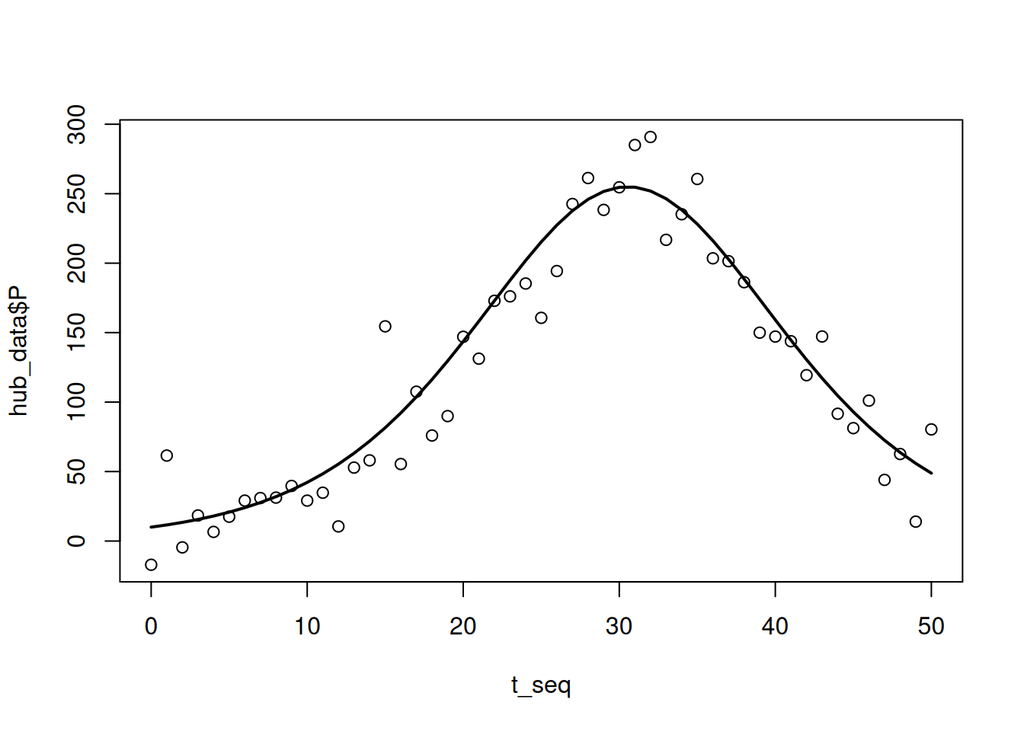

```r
# Ex 3: Hubbert Production Flow
alpha_hub <- 0.86; eta_hub <- 0.01; t0_hub <- t_seq[1]; x0_hub <- 10
hub_clean <- x0_hub*(((eta_hub + alpha_hub^t0_hub)/(eta_hub + alpha_hub^t_seq))^2)*alpha_hub^(t_seq - t0_hub)
hub_data <- data.frame(time = t_seq, P = hub_clean + rnorm(length(t_seq), mean=0, sd=27))
plot(t_seq, hub_data$P)
lines(t_seq, hub_clean, lwd = 2)
```

```r
fit_hub <- nls(P ~ x0_hub*(((eta + alpha^t0_hub)/(eta + alpha^time))^2)*alpha^(time - t0_hub), data = hub_data, start = list(eta = 0, alpha = 0.1))
summary(fit_hub)
```

```
##
## Formula: P ~ x0_hub * (((eta + alpha^t0_hub)/(eta + alpha^time))^2) *
##     alpha^(time - t0_hub)
##
## Parameters:
##        Estimate Std. Error t value Pr(>|t|)
## eta   0.0103173  0.0002875   35.88   <2e-16 ***
## alpha 0.8620008  0.0018061  477.28   <2e-16 ***
## ---
## Signif. codes:  0 '***' 0.001 '**' 0.01 '*' 0.05 '.' 0.1 ' ' 1
##
## Residual standard error: 25.32 on 49 degrees of freedom
##
## Number of iterations to convergence: 29
## Achieved convergence tolerance: 4.495e-06
```

Note: I fixed the initial observation because treating it as a free parameter caused nls to not fit the data due to a singular gradient at the start.

```r
params <- coef(fit_hub)
eta_hat  <- params["eta"]
alpha_hat <- params["alpha"]

(x_peak <- x0_hub*(eta_hat+alpha_hat^(t0_hub))^2/(4*eta_hat*alpha_hat^(t0_hub)))
```

```
##      eta
## 247.3376
```

```r
(t_peak <- log(eta_hat)/log(alpha_hat))
```

```
##      eta
## 30.80109
```

```r
(r <- -log(alpha_hat))
```

```
##     alpha
## 0.1484991
```

```r
(URR <- -x0_hub* (eta_hat+alpha_hat^(t0_hub))^2/(eta_hat*alpha_hat^(t0_hub)*log(alpha_hat)))
```

```
##      eta
## 6662.331
```

3. Based on the parameter boundaries, evaluate the main geometrical limitations of relying on this simple deterministic model if a future technological shock (such as secondary fracking recovery) occurs.

In this framework, the presence of a technological shock generating extreme observations near the peak cannot be captured by the deterministic model. Consequently, the Hubbert curve will predominantly fit the subset of data not influenced by the shock.

# Exercise 4 (Epidemiology)– Viral Outbreak Kinematics (3 points)

During the initial stage of a high-density clinical culture viral infection outbreak, the daily cumulative infected count N(t) expands rapidly without clear immediate resource limitations.

1. Formulate the Malthusian ordinary differential equation and explain why its application must be strictly restricted to early epidemic outbreaks.

EDO: $\frac{dN(t)}{dt}=rN(t)$

Note that the solution is an exponential which, for $r>0$, increases indefinitely as time goes to infinity. This assumes infinite resources, which theoretically cause an unbounded exponential growth of the population, which is not a feasible situation.

Thus, this model needs to be applied to early epidemic outbreaks, when there are a lot of resources and there exists an initial unconstrained growth phase.

2. Transform the exponential model N(t) = N0exp(rt) into a linear log-transformed framework (ln N(t) = β0 + β1t). Use the linear least squares approach (lm in R) to estimate the baseline parameter N0 and the growth speed r.

y=log(N)=log(N0)+rt. Thus, N0=exp(beta0), r=beta1.

```r
# Ex 4: Exponential Viral Outbreak (Early stage truncated to t=20)
t_early <- seq(0, 18, by = 1)
N0_vir <- 80; r_vir <- 0.18
viral_clean <- N0_vir * exp(r_vir * t_early)
viral_data <- data.frame(time = t_early, N = viral_clean + rnorm(length(t_early), mean=0, sd=10))
```

```r
fit_lm <- lm(log(N) ~ time, data = viral_data)
params <- coef(fit_lm)

beta0 <- params["(Intercept)"]
beta1 <- params["time"]
(N0=exp(beta0))
```

```
## (Intercept)
##    76.70757
```

```r
(r=beta1)
```

```
##      time
## 0.1833065
```

3. Identify at which point or capacity threshold the deterministic exponential path dramatically fails when compared to a realistic saturated epidemic profile.

The deterministic exponential growth model begins to fail as the population approaches the carrying capacity K, when resource limitations become significant and growth slows down. In contrast, when the population size is much smaller than K, the logistic model behaves approximately like exponential growth, since resource constraints are negligible and the term (1 − N/K) is close to 1. This can be seen directly from the logistic differential equation. As N approaches K, the factor (1 − N/K) approaches zero, causing the growth rate to decline and the exponential approximation to fail.